# Group32_LiverDisease

## Names , BITS ID and Dataset

Team Members

- Geetansh Kalra - 2022AC05174
- Geethu.T - 2022AC05031
- Amol Balasaheb Gaware - 2022AC05057

We are working on Liver Disease Dataset

## Import Libraries

```python
import pandas as pd
import numpy as np
import matplotlib.pyplot as plt
import seaborn as sns
from scipy import stats
from sklearn.model_selection import train_test_split, GridSearchCV
from sklearn.model_selection import KFold
from sklearn.model_selection import cross_val_score
from sklearn.preprocessing import StandardScaler
from sklearn.preprocessing import MinMaxScaler
from sklearn.ensemble import RandomForestClassifier
from sklearn.neighbors import KNeighborsClassifier
from sklearn.metrics import accuracy_score, precision_score, recall_score, roc_auc_score, roc_curve
import warnings

warnings.simplefilter(action='ignore', category=FutureWarning)
```

## Data Visualization and Exploration

```python
# Understanding what the dataset looks like

df = pd.read_csv("liver_disease_1.csv")
df.head(2)
```

|  | Age | Total_Bilirubin | Direct_Bilirubin | Alkaline_Phosphotase | Alamine_Aminotransferase | Aspartate_Aminotransferase | Total_Protiens | Albumin | Albumin_and_Globulin_Ratio | Dataset |
| --- | --- | --- | --- | --- | --- | --- | --- | --- | --- | --- |
| 0 | 65 | 0.7 | 0.1 | 187 | 16 | 18 | 6.8 | 3.3 | 0.90 | Yes |
| 1 | 62 | 10.9 | 5.5 | 699 | 64 | 100 | 7.5 | 3.2 | 0.74 | Yes |

```python
# Shape of the data
df.shape
```

```
(583, 10)
```

```python
# To understand the categorical and numerical variables in the dataset
df.info()

dfa = df.drop(columns='Dataset')
cat_columns = dfa.select_dtypes(include='object').columns.tolist()
num_columns = dfa.select_dtypes(exclude='object').columns.tolist()

print("Categorical varibales: ", cat_columns)
print("Numerical variables: ", num_columns)
```

```
<class 'pandas.core.frame.DataFrame'>
RangeIndex: 583 entries, 0 to 582
Data columns (total 10 columns):
 #   Column                      Non-Null Count  Dtype
---  ------                      --------------  -----
 0   Age                         583 non-null    int64
 1   Total_Bilirubin             583 non-null    float64
 2   Direct_Bilirubin            583 non-null    float64
 3   Alkaline_Phosphotase        583 non-null    int64
 4   Alamine_Aminotransferase    583 non-null    int64
 5   Aspartate_Aminotransferase  583 non-null    int64
 6   Total_Protiens              583 non-null    float64
 7   Albumin                     583 non-null    float64
 8   Albumin_and_Globulin_Ratio  579 non-null    float64
 9   Dataset                     583 non-null    object
dtypes: float64(5), int64(4), object(1)
memory usage: 45.7+ KB
Categorical varibales:  []
Numerical variables:  ['Age', 'Total_Bilirubin', 'Direct_Bilirubin', 'Alkaline_Phosphotase', 'Alamine_Aminotransferase', 'Aspartate_Aminotransferase', 'Total_Protiens', 'Albumin', 'Albumin_and_Globulin_Ratio']
```

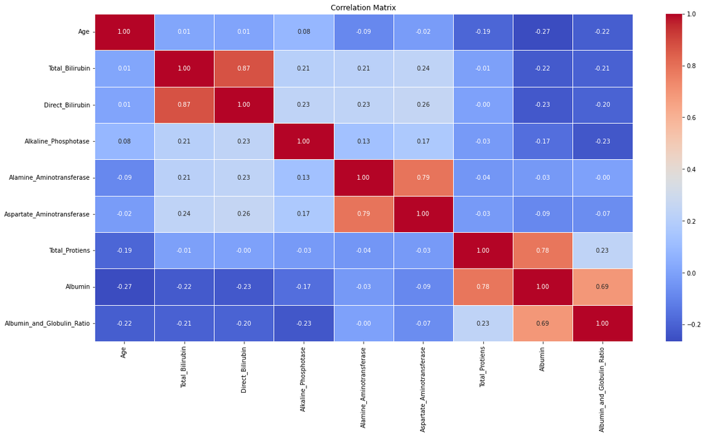

```python
correlation_matrix = df.corr(method='pearson')

plt.figure(figsize=(20, 10))
sns.heatmap(correlation_matrix, annot=True, cmap='coolwarm', fmt=".2f", linewidths=0.5)
plt.title('Correlation Matrix')
plt.show()
```

- from this we can see that Direct_Bilirubin and Total_Bilirubin; Alamine Aminotransferase and Aspartate Aminotransferase; Total Protiens and Albumin are highly correlated.

## Data Pre-processing and cleaning

```python
# Total null values in the dataset
df.isna().sum()
```

```
Age                           0
Total_Bilirubin               0
Direct_Bilirubin              0
Alkaline_Phosphotase          0
Alamine_Aminotransferase      0
Aspartate_Aminotransferase    0
Total_Protiens                0
Albumin                       0
Albumin_and_Globulin_Ratio    4
Dataset                       0
dtype: int64
```

```python
# Describing the data, To get all the stats of the data
df.describe().T
```

|  | count | mean | std | min | 25% | 50% | 75% | max |
| --- | --- | --- | --- | --- | --- | --- | --- | --- |
| Age | 583.0 | 44.746141 | 16.189833 | 4.0 | 33.0 | 45.00 | 58.0 | 90.0 |
| Total_Bilirubin | 583.0 | 3.298799 | 6.209522 | 0.4 | 0.8 | 1.00 | 2.6 | 75.0 |
| Direct_Bilirubin | 583.0 | 1.486106 | 2.808498 | 0.1 | 0.2 | 0.30 | 1.3 | 19.7 |
| Alkaline_Phosphotase | 583.0 | 290.576329 | 242.937989 | 63.0 | 175.5 | 208.00 | 298.0 | 2110.0 |
| Alamine_Aminotransferase | 583.0 | 80.713551 | 182.620356 | 10.0 | 23.0 | 35.00 | 60.5 | 2000.0 |
| Aspartate_Aminotransferase | 583.0 | 109.910806 | 288.918529 | 10.0 | 25.0 | 42.00 | 87.0 | 4929.0 |
| Total_Protiens | 583.0 | 6.483190 | 1.085451 | 2.7 | 5.8 | 6.60 | 7.2 | 9.6 |
| Albumin | 583.0 | 3.141852 | 0.795519 | 0.9 | 2.6 | 3.10 | 3.8 | 5.5 |
| Albumin_and_Globulin_Ratio | 579.0 | 0.947064 | 0.319592 | 0.3 | 0.7 | 0.93 | 1.1 | 2.8 |

```
array([[<Axes: title={'center': 'Age'}>,
        <Axes: title={'center': 'Total_Bilirubin'}>,
        <Axes: title={'center': 'Direct_Bilirubin'}>],
       [<Axes: title={'center': 'Alkaline_Phosphotase'}>,
        <Axes: title={'center': 'Alamine_Aminotransferase'}>,
        <Axes: title={'center': 'Aspartate_Aminotransferase'}>],
       [<Axes: title={'center': 'Total_Protiens'}>,
        <Axes: title={'center': 'Albumin'}>,
        <Axes: title={'center': 'Albumin_and_Globulin_Ratio'}>]],
      dtype=object)
```

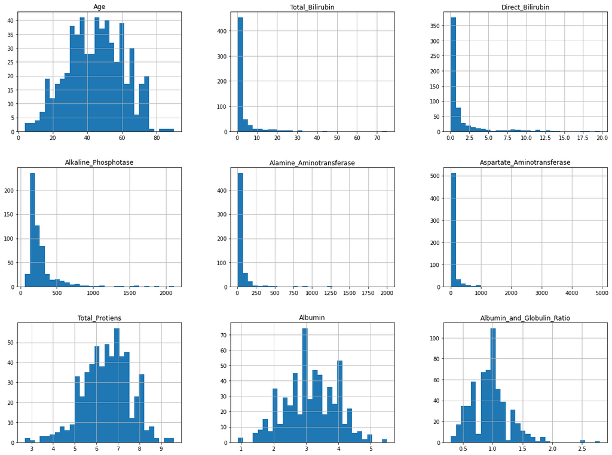

```python
df.hist(bins=30, figsize=(20,15))
```

```
Yes    416
No     167
Name: Dataset, dtype: int64
```

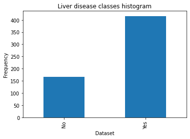

```python
count_classes = pd.value_counts(df['Dataset'], sort = True).sort_index()
count_classes.plot(kind = 'bar')
plt.title("Liver disease classes histogram")
plt.xlabel("Dataset")
plt.ylabel("Frequency")

print(df['Dataset'].value_counts())
```

- There are more Yes in the Data then there are No, we may need to handle this

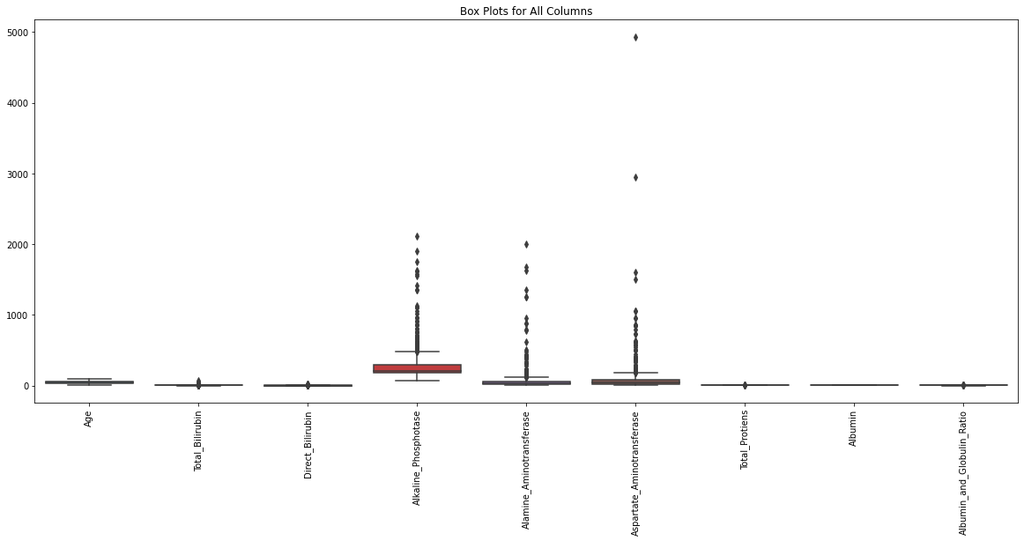

```python
plt.figure(figsize=(20, 8))
sns.boxplot(data=df)
plt.title('Box Plots for All Columns')
plt.xticks(rotation=90)
plt.show()
```

- There are many outliers in the column Alkaline_Phosphotase, Alamine_Aminotransferase, Aspartate_Aminotransferase

[figure not shown]

```python
from scipy.stats import mstats

plt.figure(figsize=(8, 6))
sns.barplot(x='Dataset', y='Alkaline_Phosphotase', data=df, ci=None)
plt.title('Bar Plot of Target Variable vs Alkaline_Phosphotase')
plt.xlabel('Target Variable')
plt.ylabel('Alkaline_Phosphotase')
plt.show()
```

[figure not shown]

```python
plt.figure(figsize=(8, 6))  # Set the size of the plot
sns.barplot(x='Dataset', y='Alamine_Aminotransferase', data=df, ci=None)  # ci=None to remove confidence intervals
plt.title('Bar Plot of Target Variable vs Alamine_Aminotransferase')
plt.xlabel('Target Variable')
plt.ylabel('Alamine_Aminotransferase')
plt.show()
```

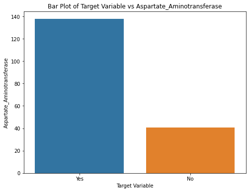

```python
plt.figure(figsize=(8, 6))  # Set the size of the plot
sns.barplot(x='Dataset', y='Aspartate_Aminotransferase', data=df, ci=None)  # ci=None to remove confidence intervals
plt.title('Bar Plot of Target Variable vs Aspartate_Aminotransferase')
plt.xlabel('Target Variable')
plt.ylabel('Aspartate_Aminotransferase')
plt.show()
```

```python
# Filling in the null values in Albumin_and_Globulin_Ratio column, There are only 4 null values so filling it with
# mean seems the most appropriate as the columns data is almost normally distributed or the best we can say is that
# it's not skewed

print("Albumin_and_Globulin_Ratio column mean is:" ,  df['Albumin_and_Globulin_Ratio'].mean())
df['Albumin_and_Globulin_Ratio'].fillna(df['Albumin_and_Globulin_Ratio'].mean(), inplace=True)
```

```
Albumin_and_Globulin_Ratio column mean is: 0.9470639032815201
```

- From above analysis we already know that Missing values have been filled
- There are outliers though, we need to fix that issue
- We will use two techniques to handle outliers, And do testing on both these techniques to check the result on which performs better
  - Technique one: We will remove all the outliers
  - Technique two: We will modify the values using Logarithmic transformation, as this converts our skewed curve into a better curve, making the data more symmetric

### Technique One: Removing Outliers By keeping Threshold 3

```python
threshold = 3

z_scores_column1 = np.abs(stats.zscore(df['Alkaline_Phosphotase']))
z_scores_column2 = np.abs(stats.zscore(df['Alamine_Aminotransferase']))
z_scores_column3 = np.abs(stats.zscore(df['Aspartate_Aminotransferase']))

outlier_mask_column1 = z_scores_column1 > threshold
outlier_mask_column2 = z_scores_column2 > threshold
outlier_mask_column3 = z_scores_column3 > threshold

any_outlier_mask = (outlier_mask_column1 | outlier_mask_column2 | outlier_mask_column3)

df_no_outliers = df[~any_outlier_mask]

print(df_no_outliers['Dataset'].value_counts())
```

[output not shown]

- After keeping a threshold of 3, we removed the outliers, The new length of the dataset is 559 from 583, So not many datapoints have been removed.
- Now the Yes data points are 393 and No data points are 166 from 416 and 167 respectively.

### Technique Two: Using Logarithmic Transformation

```python
df_log_transformed = df.copy()

df_log_transformed['Alkaline_Phosphotase'] = np.where(df_log_transformed['Alkaline_Phosphotase'] > 0, np.log(df_log_transformed['Alkaline_Phosphotase']), 0)
df_log_transformed['Alamine_Aminotransferase'] = np.where(df_log_transformed['Alamine_Aminotransferase'] > 0, np.log(df_log_transformed['Alamine_Aminotransferase']), 0)
df_log_transformed['Aspartate_Aminotransferase'] = np.where(df_log_transformed['Aspartate_Aminotransferase'] > 0, np.log(df_log_transformed['Aspartate_Aminotransferase']), 0)
df_log_transformed['Total_Bilirubin'] = np.where(df_log_transformed['Total_Bilirubin'] > 0, np.log(df_log_transformed['Total_Bilirubin']), 0)
df_log_transformed['Direct_Bilirubin'] = np.where(df_log_transformed['Direct_Bilirubin'] > 0, np.log(df_log_transformed['Direct_Bilirubin']), 0)
```

```python
df['Dataset']=df['Dataset'].apply(lambda x:1 if x=='Yes' else 0)
df.head(2)
```

|  | Age | Total_Bilirubin | Direct_Bilirubin | Alkaline_Phosphotase | Alamine_Aminotransferase | Aspartate_Aminotransferase | Total_Protiens | Albumin | Albumin_and_Globulin_Ratio | Dataset |
| --- | --- | --- | --- | --- | --- | --- | --- | --- | --- | --- |
| 0 | 65 | 0.7 | 0.1 | 187 | 16 | 18 | 6.8 | 3.3 | 0.90 | 1 |
| 1 | 62 | 10.9 | 5.5 | 699 | 64 | 100 | 7.5 | 3.2 | 0.74 | 1 |

- Since we know that ML models don't work on string or categorical variables, we will convert our Dataset to numerical values
- We also need to apply feature transformation techniques like Standardization, Normalization to get all columns in the same range

### Normalising the Dataset: Using Min Max Scaling

```python
def normalise_dataset(df):
    X = df.drop(columns=['Dataset'])
    y = df['Dataset']

    scaler = MinMaxScaler()

    X_normalized = scaler.fit_transform(X)

    df_normalized = pd.DataFrame(X_normalized, columns=X.columns)

    df_normalized['Target'] = y

    return df_normalized
```

## Model Building

```python
def split_data(dataframe, test_size):
    # splitting data into train and test

    X = dataframe.drop(['Dataset'], axis=1)
    y = dataframe['Dataset']

    X_train, X_test, y_train, y_test = train_test_split(X, y, test_size=test_size, random_state=42)

    print("Results for test size: ", test_size*100, 'percent')
    return X, y, X_train, X_test, y_train, y_test
```

- With a single train-test split, the model's performance may be highly dependent on the particular random partitioning of the data. K-fold cross-validation mitigates this by averaging the model's performance over multiple train-test splits. This provides a more robust and reliable estimate of how well the model generalizes to unseen data.

```python
def k_fold_validation(X, y):
    k = 5

    # Create the k-fold cross-validation object
    kf = KFold(n_splits=k, shuffle=True, random_state=42)

    model = RandomForestClassifier()

    scores = cross_val_score(model, X, y, cv=kf)

    print("Cross-validation scores for RandomForest:", scores)
    print("Mean CV score for RandomForest:", scores.mean())

    kf = KFold(n_splits=k, shuffle=True, random_state=42)
    model = KNeighborsClassifier()

    scores = cross_val_score(model, X, y, cv=kf)

    print("Cross-validation scores for KNN:", scores)
    print("Mean CV score for KNN:", scores.mean())
```

```python
def train_model_and_results_for_random_forrest(X_train, y_train, X_test, y_test):

    param_grid = {
        'n_estimators': [10, 20, 30, 40, 50],     # Number of trees in the forest
        'max_depth': [None, 1, 2, 3, 4, 5],       # Maximum depth of each tree
        'min_samples_split': [2, 5, 10],       # Minimum samples required to split an internal node
        'min_samples_leaf': [1, 2, 4],         # Minimum samples required to be at a leaf node
        'max_features': ['auto', 'sqrt', 'log2']  # Number of features to consider at each split
    }

    rf_classifier = RandomForestClassifier(random_state=42)

    grid_search = GridSearchCV(estimator=rf_classifier, param_grid=param_grid, cv=5, scoring='accuracy')
    grid_search.fit(X_train, y_train)

    best_params = grid_search.best_params_

    best_rf_classifier = RandomForestClassifier(random_state=42, **best_params)
    best_rf_classifier.fit(X_train, y_train)

    rf_predictions = best_rf_classifier.predict(X_test)

    rf_accuracy = accuracy_score(y_test, rf_predictions)

    print("Best Hyperparameters for Random Forrest:", best_params)
    print("Random Forest Accuracy with Best Hyperparameters:", rf_accuracy)
```

```python
def train_model_and_results_for_KNN(X_train, y_train, X_test, y_test):

    k_values = np.arange(1, 11)

    accuracy_scores = []

    for k in k_values:
        knn = KNeighborsClassifier(n_neighbors=k)
        knn.fit(X_train, y_train)
        y_pred = knn.predict(X_test)
        accuracy = accuracy_score(y_test, y_pred)
        accuracy_scores.append(accuracy)

    plt.figure(figsize=(8, 6))
    plt.plot(k_values, accuracy_scores, marker='o', linestyle='-', color='b')
    plt.title('Elbow Method for Optimal K')
    plt.xlabel('Number of Neighbors (K)')
    plt.ylabel('Accuracy')
    plt.grid(True)
    plt.show()
```

- Metrics Chosen
  - Accuracy: Accuracy is the most straightforward metric and is often used as a general performance measure. It calculates the ratio of correctly predicted instances to the total number of instances. However, accuracy may not be suitable for imbalanced datasets.
  - Precision and Recall: These metrics are important when dealing with imbalanced datasets. Precision measures the ratio of correctly predicted positive instances to the total predicted positive instances. Recall (Sensitivity or True Positive Rate) measures the ratio of correctly predicted positive instances to the total actual positive instances
  - Area Under the Receiver Operating Characteristic Curve (AUC-ROC): ROC curves plot the True Positive Rate (TPR) against the False Positive Rate (FPR) at various threshold settings. AUC-ROC measures the area under the ROC curve and is used to evaluate binary classification models. It quantifies the model's ability to distinguish between positive and negative classes.

# Run Below Code this for Getting Optimal Values

[output not shown]

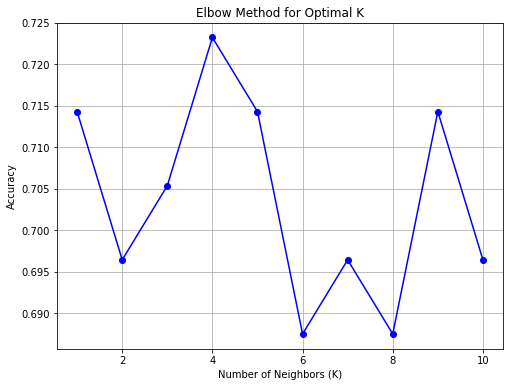

```python
## For Data with threshold of 3, No outliers Dataset: df_no_outliers

X, y, X_train, X_test, y_train, y_test = split_data(df_no_outliers, 2/10)
k_fold_validation(X, y)
train_model_and_results_for_random_forrest(X_train, y_train, X_test, y_test)
train_model_and_results_for_KNN(X_train, y_train, X_test, y_test)
print('*' * 100)
```

[output not shown]

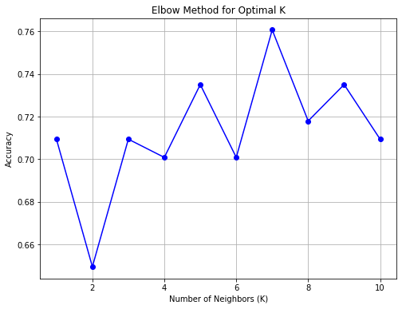

```python
## For Data with Log Transformation: df_log_transformed

X, y, X_train, X_test, y_train, y_test = split_data(df_log_transformed, 2/10)
k_fold_validation(X, y)
train_model_and_results_for_random_forrest(X_train, y_train, X_test, y_test)
train_model_and_results_for_KNN(X_train, y_train, X_test, y_test)
print('*' * 100)
```

## Random Forrest with best Hyperparameters

```
Results for test size:  20.0 percent
Random Forest Accuracy with Best Hyperparameters: 0.7435897435897436
Random Forest Precision with Best Hyperparameters: 0.7435897435897436
Random Forest Recall with Best Hyperparameters: 1.0
Random Forest ROC AUC with Best Hyperparameters: 0.8153256704980844
```

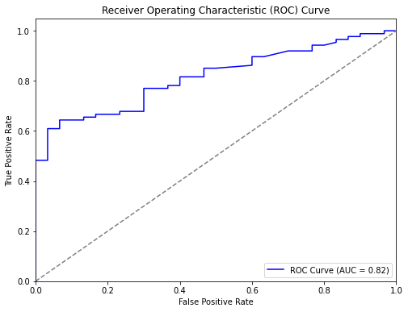

```python
X, y, X_train, X_test, y_train, y_test = split_data(df_log_transformed, 2/10)

rf_classifier = RandomForestClassifier(n_estimators=30, max_depth=2)
rf_classifier.fit(X_train, y_train)

rf_predictions = rf_classifier.predict(X_test)

rf_accuracy = accuracy_score(y_test, rf_predictions)
rf_precision = precision_score(y_test, rf_predictions)
rf_recall = recall_score(y_test, rf_predictions)
rf_roc_auc = roc_auc_score(y_test, rf_classifier.predict_proba(X_test)[:, 1])

print("Random Forest Accuracy with Best Hyperparameters:", rf_accuracy)
print("Random Forest Precision with Best Hyperparameters:", rf_precision)
print("Random Forest Recall with Best Hyperparameters:", rf_recall)
print("Random Forest ROC AUC with Best Hyperparameters:", rf_roc_auc)

fpr, tpr, thresholds = roc_curve(y_test, rf_classifier.predict_proba(X_test)[:, 1])
plt.figure(figsize=(8, 6))
plt.plot(fpr, tpr, color='b', label='ROC Curve (AUC = {:.2f})'.format(rf_roc_auc))
plt.plot([0, 1], [0, 1], color='gray', linestyle='--')
plt.xlim([0.0, 1.0])
plt.ylim([0.0, 1.05])
plt.xlabel('False Positive Rate')
plt.ylabel('True Positive Rate')
plt.title('Receiver Operating Characteristic (ROC) Curve')
plt.legend(loc='lower right')
plt.show()
```

## KNN with Best K value

```
KNN Accuracy with Best Hyperparameters: 0.7606837606837606
KNN Precision with Best Hyperparameters: 0.8470588235294118
KNN Recall with Best Hyperparameters: 0.8275862068965517
KNN ROC AUC with Best Hyperparameters: 0.7827586206896551
```

[figure not shown]

```python
X, y, X_train, X_test, y_train, y_test = split_data(df_log_transformed, 2/10)

knn_classifier = KNeighborsClassifier(n_neighbors=7)
knn_classifier.fit(X_train, y_train)
knn_pred = knn_classifier.predict(X_test)

knn_accuracy = accuracy_score(y_test, knn_pred)
knn_precision = precision_score(y_test, knn_pred)
knn_recall = recall_score(y_test, knn_pred)
knn_roc_auc = roc_auc_score(y_test, knn_classifier.predict_proba(X_test)[:, 1])

print("KNN Accuracy with Best Hyperparameters:", knn_accuracy)
print("KNN Precision with Best Hyperparameters:", knn_precision)
print("KNN Recall with Best Hyperparameters:", knn_recall)
print("KNN ROC AUC with Best Hyperparameters:", knn_roc_auc)

fpr, tpr, thresholds = roc_curve(y_test, knn_classifier.predict_proba(X_test)[:, 1])
plt.figure(figsize=(8, 6))
plt.plot(fpr, tpr, color='b', label='ROC Curve (AUC = {:.2f})'.format(rf_roc_auc))
plt.plot([0, 1], [0, 1], color='gray', linestyle='--')
plt.xlim([0.0, 1.0])
plt.ylim([0.0, 1.05])
plt.xlabel('False Positive Rate')
plt.ylabel('True Positive Rate')
plt.title('Receiver Operating Characteristic (ROC) Curve')
plt.legend(loc='lower right')
plt.show()
```